# A/B Testing

The Cookie Cats dataset used in this A/B test is from [Kaggle](https://www.kaggle.com/datasets/arpitdw/cokie-cats?). It is a dataset for a mobile game with the following fields:

- **userid**: A unique identifier for each player.
- **version**: Indicates whether the player was assigned the game with level 1 at Gate 30 or Gate 40
- **sum_gamerounds**: Number of rounds played in the first week after installation.
- **retention_1**: Binary variable on whether the player returned to play one day after installing.
- **retention_7**: Binary variable on whether the player returned to play seven days after installing.

## A/B Test Setup

**Question**: Does shifting the placement of the first gate from Gate 30 to Gate 40 impact player retention?

**Hypothesis**:

- H0: Proportions of retention after day 1 and day 7 are equal for Gate 30 and Gate 40 players.
- H1: Proportions of retention after day 1 and day 7 are different between Gate 30 and Gate 40 players.

**Groups**:

- Control group: Gate 30 players
- Treatment group: Gate 40 players

**Metrics**:

- Player retention after 1 day
- Player retention after 7 days

```python
# import libraries
import pandas as pd
import numpy as np
from scipy import stats
from scipy.stats import chi2_contingency
from statsmodels.stats.power import NormalIndPower
from statsmodels.stats.proportion import proportion_effectsize
import matplotlib.pyplot as plt
import sklearn
import seaborn as sns
import plotly.express as px
from plotly import graph_objects as go
```

## Exploratory Data Analysis

```python
# import dataset and conduct EDA
df = pd.read_csv('cookie_cats.csv')
display(df.info())
display(df.sample(5))
```

```
<class 'pandas.core.frame.DataFrame'>
RangeIndex: 90189 entries, 0 to 90188
Data columns (total 5 columns):
 #   Column          Non-Null Count  Dtype
---  ------          --------------  -----
 0   userid          90189 non-null  int64
 1   version         90189 non-null  object
 2   sum_gamerounds  90189 non-null  int64
 3   retention_1     90189 non-null  bool
 4   retention_7     90189 non-null  bool
dtypes: bool(2), int64(2), object(1)
memory usage: 2.2+ MB
```

```
None
```

|  | userid | version | sum_gamerounds | retention_1 | retention_7 |
| --- | --- | --- | --- | --- | --- |
| 86231 | 9551741 | gate_40 | 3 | False | False |
| 66464 | 7358583 | gate_40 | 31 | False | True |
| 63210 | 7000951 | gate_30 | 6 | False | False |
| 33156 | 3682980 | gate_30 | 136 | True | True |
| 80847 | 8953465 | gate_40 | 30 | True | False |

```python
# Function to create bar plot
def bar_plot_series(series, xlabel, ylabel, title):
    plt.figure(figsize=(4, 3))
    ax = series.plot(kind='bar')

    for i, value in enumerate(series):
        ax.text(i, value + value * 0.01, f'{value:,.0f}', ha='center', va='bottom', fontsize=10)

    plt.xlabel(xlabel)
    plt.ylabel(ylabel)
    plt.title(title)
    plt.xticks(rotation=0)
    plt.tight_layout()
    plt.show()
```

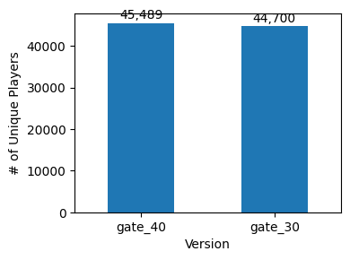

```python
pd.options.display.float_format = '{:,.0f}'.format # format floats for readability
n_players_by_version = df['version'].value_counts()
bar_plot_series(n_players_by_version, 'Version', "# of Unique Players", "")
```

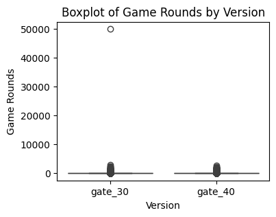

```python
plt.figure(figsize=(4, 3))
sns.boxplot(x='version', y='sum_gamerounds', data=df)
plt.xlabel('Version')
plt.ylabel('Game Rounds')
plt.title('Boxplot of Game Rounds by Version')
plt.show()
```

```python
# Find outliers
Q1 = df['sum_gamerounds'].quantile(0.25)
Q3 = df['sum_gamerounds'].quantile(0.75)
IQR = Q3 - Q1
outliers = df[(df['sum_gamerounds'] < Q1 - 1.5 * IQR) | (df['sum_gamerounds'] > Q3 + 1.5 * IQR)]
print(f"Outliers IQR Method: {len(outliers)}")

mean = df['sum_gamerounds'].mean()
std_dev = df['sum_gamerounds'].std()
df['Z_score'] = np.abs((df['sum_gamerounds'] - mean) / std_dev)
outliers_z = df[df['Z_score'] > 7]
print(f"Outliers Z-Score Method: {len(outliers_z)}")
display(outliers_z)

# Decided not to remove outliers
# df = df[df['userid']!=6390605]
# df = df[df['sum_gamerounds']>0]
```

```
Outliers IQR Method: 10177
Outliers Z-Score Method: 34
```

|  | userid | version | sum_gamerounds | retention_1 | retention_7 | Z_score |
| --- | --- | --- | --- | --- | --- | --- |
| 655 | 69927 | gate_30 | 1906 | True | True | 10 |
| 4592 | 511737 | gate_30 | 1425 | True | True | 7 |
| 5536 | 614199 | gate_40 | 1446 | True | True | 7 |
| 6536 | 725080 | gate_40 | 2015 | True | True | 10 |
| 7912 | 871500 | gate_30 | 2961 | True | True | 15 |
| 10683 | 1179503 | gate_40 | 1573 | True | True | 8 |
| 11858 | 1310015 | gate_40 | 1697 | True | True | 8 |
| 12410 | 1374546 | gate_40 | 1643 | True | True | 8 |
| 13320 | 1476122 | gate_30 | 1705 | True | True | 8 |
| 18586 | 2067556 | gate_40 | 1816 | True | True | 9 |
| 19057 | 2119064 | gate_40 | 1687 | True | True | 8 |
| 26308 | 2930290 | gate_40 | 1559 | True | True | 8 |
| 26930 | 3000588 | gate_30 | 1491 | True | True | 7 |
| 27116 | 3020754 | gate_30 | 1522 | True | True | 8 |
| 27515 | 3064157 | gate_30 | 1714 | True | True | 9 |
| 29417 | 3271615 | gate_40 | 2640 | True | False | 13 |
| 33779 | 3748828 | gate_40 | 1643 | True | True | 8 |
| 36933 | 4090246 | gate_40 | 2124 | True | True | 11 |
| 38714 | 4288672 | gate_40 | 1462 | True | True | 7 |
| 39881 | 4415630 | gate_40 | 1558 | True | True | 8 |
| 41384 | 4578716 | gate_30 | 1469 | True | True | 7 |
| 41639 | 4606929 | gate_30 | 1528 | True | True | 8 |
| 43671 | 4832608 | gate_30 | 2438 | True | True | 12 |
| 46344 | 5133952 | gate_30 | 2251 | True | True | 11 |
| 48188 | 5346171 | gate_40 | 2294 | True | True | 11 |
| 50650 | 5613511 | gate_30 | 1457 | True | True | 7 |
| 51983 | 5764651 | gate_30 | 1544 | True | True | 8 |
| 54118 | 6008689 | gate_40 | 1427 | True | True | 7 |
| 57702 | 6390605 | gate_30 | 49854 | False | True | 255 |
| 80837 | 8952445 | gate_40 | 1529 | True | True | 8 |
| 83633 | 9268906 | gate_40 | 1667 | True | True | 8 |
| 84885 | 9409315 | gate_30 | 1490 | True | True | 7 |
| 87007 | 9640085 | gate_30 | 2156 | True | True | 11 |
| 88328 | 9791599 | gate_40 | 2063 | True | True | 10 |

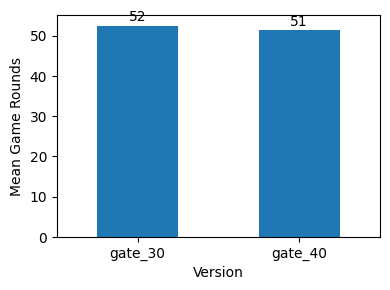

```python
mean_gamerounds = df.groupby('version')['sum_gamerounds'].mean()
bar_plot_series(mean_gamerounds, 'Version', "Mean Game Rounds", "")
```

```
Observed Means - Proportion Retained:
Gate 30 1-day retention: 44.82%
Gate 40 1-day retention: 44.23%
Gate 30 7-day retention: 19.02%
Gate 40 7-day retention: 18.2%
```

| version | retention_1 False | retention_1 True | retention_7 False | retention_7 True |
| --- | --- | --- | --- | --- |
| gate_30 | 24666 | 20034 | 36198 | 8502 |
| gate_40 | 25370 | 20119 | 37210 | 8279 |

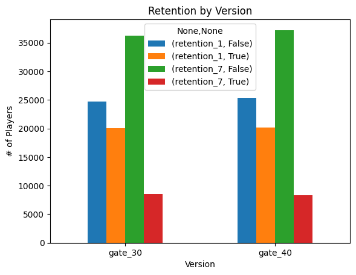

```python
retention = df.groupby('version')[['retention_1', 'retention_7']].apply(lambda x: x.apply(lambda col: pd.Series(col).value_counts())).unstack(fill_value=0)

obs_gate30_ret1 = retention.iloc[0,1] / (retention.iloc[0,0] + retention.iloc[0,1])
obs_gate40_ret1 = retention.iloc[1,1] / (retention.iloc[1,0] + retention.iloc[1,1])
obs_gate30_ret7 = retention.iloc[0,3] / (retention.iloc[0,2] + retention.iloc[0,3])
obs_gate40_ret7 = retention.iloc[1,3] / (retention.iloc[1,2] + retention.iloc[1,3])

print(f"Observed Means - Proportion Retained:")
print(f"Gate 30 1-day retention: {round(obs_gate30_ret1*100,2)}%")
print(f"Gate 40 1-day retention: {round(obs_gate40_ret1*100,2)}%")
print(f"Gate 30 7-day retention: {round(obs_gate30_ret7*100,2)}%")
print(f"Gate 40 7-day retention: {round(obs_gate40_ret7*100,2)}%")

display(retention)

retention.plot(kind='bar', stacked=False)
plt.title('Retention by Version')
plt.xlabel('Version')
plt.ylabel('# of Players')
plt.xticks(rotation=0)
plt.show()
```

```python
def convert_bool_to_int(value):
    if value:
        return 1
    else:
        return 0

df['retention_1'] = df['retention_1'].apply(convert_bool_to_int)
df['retention_7'] = df['retention_7'].apply(convert_bool_to_int)
df.head(2)
```

|  | userid | version | sum_gamerounds | retention_1 | retention_7 | Z_score |
| --- | --- | --- | --- | --- | --- | --- |
| 0 | 116 | gate_30 | 3 | 0 | 0 | 0 |
| 1 | 337 | gate_30 | 38 | 1 | 0 | 0 |

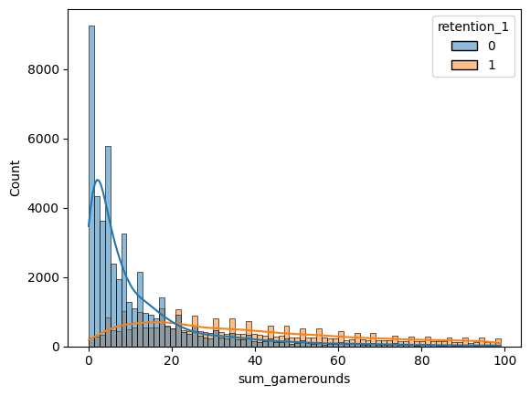

```python
sns.histplot(df.loc[df["sum_gamerounds"]<100], kde=True, x="sum_gamerounds", hue="retention_1")
```

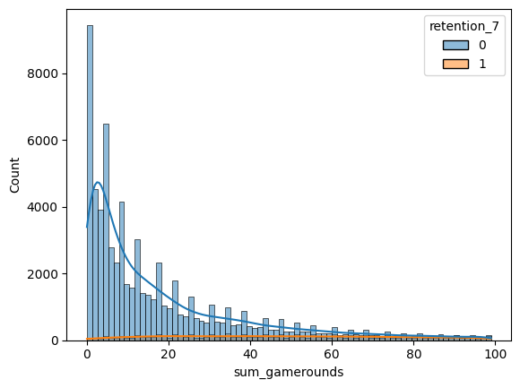

```python
sns.histplot(df.loc[df["sum_gamerounds"]<100], kde=True, x="sum_gamerounds", hue="retention_7")
```

```python
n_users = df.userid.nunique()

gate_30_data = df[df["version"]=="gate_30"]
gate_40_data = df[df["version"]=="gate_40"]

stages = ["Downloads", "1-Round Player", "1-day Retention", "7-day Retention"]

values_30 = [gate_30_data.userid.nunique(), # num of game_30 users
             gate_30_data[gate_30_data["sum_gamerounds"]>0].userid.nunique(), # game_30 users played 1+ round
             gate_30_data.retention_1.sum(), # came back after 1 day
             gate_30_data.retention_7.sum()] # came back after 7 days

percentage_30 = [str(round(values_30[i]/n_users*100, 1)) + "% of all users" + "<br>"
                 + str(round(values_30[i]/gate_30_data.userid.nunique()*100, 1)) + "% of group" for i in range(len(values_30))]

values_30 = pd.DataFrame(dict(number=values_30, stage=stages, percentage=percentage_30))
values_30["group"] = "gate_30"

values_40 = [gate_40_data.userid.nunique(), gate_40_data[gate_40_data["sum_gamerounds"]>0].userid.nunique(),
             gate_40_data.retention_1.sum(), gate_40_data.retention_7.sum()]

percentage_40 = [str(round(values_40[i]/n_users*100, 1)) + "% of all users" + "<br>"
                 + str(round(values_40[i]/gate_40_data.userid.nunique()*100, 1)) + "% of group" for i in range(len(values_40))]
values_40 = pd.DataFrame(dict(number=values_40, stage=stages, percentage=percentage_40))
values_40["group"] = "gate_40"

funnel_data = pd.concat([values_30, values_40], axis=0)
display(funnel_data)

fig = px.funnel(funnel_data, x='number', y='stage', color='group', text="percentage", title="Game Conversion")
fig.show()
```

|  | number | stage | percentage | group |
| --- | --- | --- | --- | --- |
| 0 | 44700 | Downloads | 49.6% of all users<br>100.0% of group | gate_30 |
| 1 | 42763 | 1-Round Player | 47.4% of all users<br>95.7% of group | gate_30 |
| 2 | 20034 | 1-day Retention | 22.2% of all users<br>44.8% of group | gate_30 |
| 3 | 8502 | 7-day Retention | 9.4% of all users<br>19.0% of group | gate_30 |
| 0 | 45489 | Downloads | 50.4% of all users<br>100.0% of group | gate_40 |
| 1 | 43432 | 1-Round Player | 48.2% of all users<br>95.5% of group | gate_40 |
| 2 | 20119 | 1-day Retention | 22.3% of all users<br>44.2% of group | gate_40 |
| 3 | 8279 | 7-day Retention | 9.2% of all users<br>18.2% of group | gate_40 |

[interactive chart not shown]

## Statistical Testing

```python
contingency_table = pd.crosstab(df['version'], df['retention_1'])
display(contingency_table)

contingency_table = pd.crosstab(df['version'], df['retention_7'])
display(contingency_table)
```

| retention_1 version | 0 | 1 |
| --- | --- | --- |
| gate_30 | 24666 | 20034 |
| gate_40 | 25370 | 20119 |

| retention_7 version | 0 | 1 |
| --- | --- | --- |
| gate_30 | 36198 | 8502 |
| gate_40 | 37210 | 8279 |

### Power Analysis

```python
power = 0.8
alpha = 0.05
d = 0.1 # desired effect size (difference between proportions of retention for Gates 30 & 40)
proportion_30_ret1 = 0.5 + d/2
proportion_40_ret1 = 0.5 - d/2

effect_size = proportion_effectsize(proportion_30_ret1, proportion_40_ret1)

analysis = NormalIndPower()
sample_size = analysis.solve_power(effect_size=effect_size, alpha=alpha, power=power, alternative='two-sided')

print(f"Required sample size for Group A: {sample_size:.0f}")
print(f"Required sample size for Group B: {sample_size:.0f}")
```

```
Required sample size for Group A: 391
Required sample size for Group B: 391
```

### Bootstrap Sampling

```python
# Conduct bootstrap sampling
def bootstrap_sampling(data, n_samples=10000, sample_size=None):
    if sample_size is None:
        sample_size = len(data)
    bootstrap_samples = np.zeros(n_samples) # array to store bootstrap samples
    for i in range(n_samples):
        bootstrap_sample = np.random.choice(data, size=sample_size, replace=True)
        bootstrap_samples[i] = np.mean(bootstrap_sample)
    return bootstrap_samples

bs_30_ret1 = bootstrap_sampling(gate_30_data['retention_1'])
bs_30_ret7 = bootstrap_sampling(gate_30_data['retention_7'])
bs_40_ret1 = bootstrap_sampling(gate_40_data['retention_1'])
bs_40_ret7 = bootstrap_sampling(gate_40_data['retention_7'])

bs_mean_30_1 = np.mean(bs_30_ret1)
bs_mean_30_7 = np.mean(bs_30_ret7)
bs_mean_40_1 = np.mean(bs_40_ret1)
bs_mean_40_7 = np.mean(bs_40_ret7)

confidence_level = 1 - alpha
lower_ci_30_1, upper_ci_30_1 = np.quantile(bs_30_ret1, [(1-confidence_level)/2, 1 - (1-confidence_level)/2])
lower_ci_40_1, upper_ci_40_1 = np.quantile(bs_40_ret1, [(1-confidence_level)/2, 1 - (1-confidence_level)/2])
lower_ci_30_7, upper_ci_30_7 = np.quantile(bs_30_ret7, [(1-confidence_level)/2, 1 - (1-confidence_level)/2])
lower_ci_40_7, upper_ci_40_7 = np.quantile(bs_40_ret7, [(1-confidence_level)/2, 1 - (1-confidence_level)/2])

print("Gate 30, 1-day Retention:")
print(f"Bootstrap Mean: {bs_mean_30_1:.2f}")
print(f"{int(confidence_level*100)}% Confidence Interval: ({lower_ci_30_1:.2f}, {upper_ci_30_1:.2f})")
print()
print("Gate 40, 1-day Retention:")
print(f"Bootstrap Mean: {bs_mean_40_1:.2f}")
print(f"{int(confidence_level*100)}% Confidence Interval: ({lower_ci_40_1:.2f}, {upper_ci_40_1:.2f})")
print()
print("Gate 30, 7-day Retention:")
print(f"Bootstrap Mean: {bs_mean_30_7:.2f}")
print(f"{int(confidence_level*100)}% Confidence Interval: ({lower_ci_30_7:.2f}, {upper_ci_30_7:.2f})")
print()
print("Gate 40, 7-day Retention:")
print(f"Bootstrap Mean: {bs_mean_40_7:.2f}")
print(f"{int(confidence_level*100)}% Confidence Interval: ({lower_ci_40_7:.2f}, {upper_ci_40_7:.2f})")
```

```
Gate 30, 1-day Retention:
Bootstrap Mean: 0.45
95% Confidence Interval: (0.44, 0.45)

Gate 40, 1-day Retention:
Bootstrap Mean: 0.44
95% Confidence Interval: (0.44, 0.45)

Gate 30, 7-day Retention:
Bootstrap Mean: 0.19
95% Confidence Interval: (0.19, 0.19)

Gate 40, 7-day Retention:
Bootstrap Mean: 0.18
95% Confidence Interval: (0.18, 0.19)
```

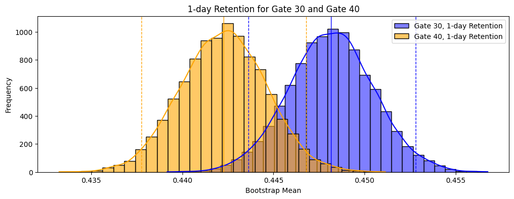

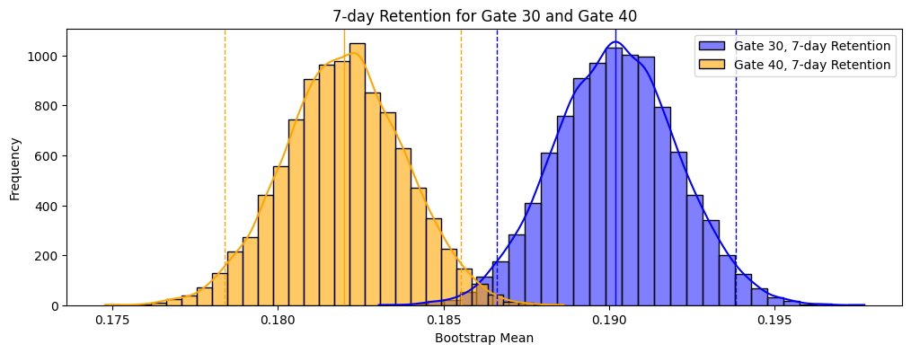

```python
# Visualization
plt.figure(figsize=(12, 4))

sns.histplot(bs_30_ret1, bins=30, kde=True, color='blue', label='Gate 30, 1-day Retention')
sns.histplot(bs_40_ret1, bins=30, kde=True, color='orange', label='Gate 40, 1-day Retention', alpha=0.6)

plt.axvline(bs_mean_30_1, color='blue', linestyle='solid', linewidth=1)
plt.axvline(lower_ci_30_1, color='blue', linestyle='dashed', linewidth=1)
plt.axvline(upper_ci_30_1, color='blue', linestyle='dashed', linewidth=1)
plt.axvline(bs_mean_40_1, color='orange', linestyle='solid', linewidth=1)
plt.axvline(lower_ci_40_1, color='orange', linestyle='dashed', linewidth=1)
plt.axvline(upper_ci_40_1, color='orange', linestyle='dashed', linewidth=1)

plt.title('1-day Retention for Gate 30 and Gate 40')
plt.xlabel('Bootstrap Mean')
plt.ylabel('Frequency')
plt.legend()
plt.show()

# Visualization for 7-day retention
plt.figure(figsize=(12, 4))

sns.histplot(bs_30_ret7, bins=30, kde=True, color='blue', label='Gate 30, 7-day Retention')
sns.histplot(bs_40_ret7, bins=30, kde=True, color='orange', label='Gate 40, 7-day Retention', alpha=0.6)

plt.axvline(bs_mean_30_7, color='blue', linestyle='solid', linewidth=1)
plt.axvline(lower_ci_30_7, color='blue', linestyle='dashed', linewidth=1)
plt.axvline(upper_ci_30_7, color='blue', linestyle='dashed', linewidth=1)
plt.axvline(bs_mean_40_7, color='orange', linestyle='solid', linewidth=1)
plt.axvline(lower_ci_40_7, color='orange', linestyle='dashed', linewidth=1)
plt.axvline(upper_ci_40_7, color='orange', linestyle='dashed', linewidth=1)

plt.title('7-day Retention for Gate 30 and Gate 40')
plt.xlabel('Bootstrap Mean')
plt.ylabel('Frequency')
plt.legend()
plt.show()
```

## Hypothesis Testing Results

```python
# Calculate difference between groups
bs_ret1_diff = bs_30_ret1 - bs_40_ret1
bs_ret7_diff = bs_30_ret7 - bs_40_ret7

# H0: Gate 30 and 40 have no difference (d=0)
# H1: Gate 30 and 30 are different (d!=0)
low_ci1, high_ci1 = np.quantile(bs_ret1_diff, [(1-confidence_level)/2, 1 - (1-confidence_level)/2])
low_ci7, high_ci7 = np.quantile(bs_ret7_diff, [(1-confidence_level)/2, 1 - (1-confidence_level)/2])

# Calculate observed difference
mean_diff_ret1 = np.mean(bs_ret1_diff)
print(f"Observed difference between Gate 30 & 40 1-day Retention: {round(mean_diff_ret1*100,3)}%")
mean_diff_ret7 = np.mean(bs_ret7_diff)
print(f"Observed difference between Gate 30 & 40 7-day Retention: {round(mean_diff_ret7*100,3)}%")
```

```
Observed difference between Gate 30 & 40 1-day Retention: 0.591%
Observed difference between Gate 30 & 40 7-day Retention: 0.821%
```

```
P-value 1-day Retention: 0.0757
```

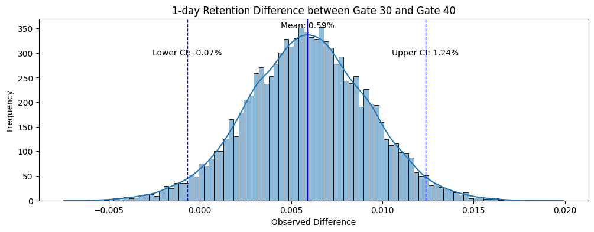

```python
# Calculate p-value - the proportion of bootstrap differences that are as or more extreme than the observed difference
p_value_ret1 = np.mean(bs_ret1_diff <= 0) + np.mean(bs_ret1_diff >= high_ci1-(0-low_ci1))

print(f"P-value 1-day Retention: {p_value_ret1}")
plt.figure(figsize=(12, 4))

sns.histplot(bs_ret1_diff, bins=100, kde=True)

plt.axvline(mean_diff_ret1, color='blue', linestyle='solid', linewidth=1)
plt.axvline(high_ci1, color='blue', linestyle='dashed', linewidth=1)
plt.axvline(low_ci1, color='blue', linestyle='dashed', linewidth=1)

# Adding text labels for the lines
plt.text(mean_diff_ret1, plt.ylim()[1]*.95, f'Mean: {mean_diff_ret1*100:.2f}%', ha='center')
plt.text(high_ci1, plt.ylim()[1]*0.8, f'Upper CI: {high_ci1*100:.2f}%', ha='center')
plt.text(low_ci1, plt.ylim()[1]*0.8, f'Lower CI: {low_ci1*100:.2f}%', ha='center')

plt.title('1-day Retention Difference between Gate 30 and Gate 40')
plt.xlabel('Observed Difference')
plt.ylabel('Frequency')
plt.show()
```

The p-value is greater than alpha. Also, 0 is in the confidence interval. There is not enough evidence to reject the null hypothesis for 1-day retention. There is no difference in 1-day retention if the gate is at 30 or 40.

```
P-value 7-day Retention: 0.002
Mean 7-day Retention Proportion Gate 30: 19.02%
Mean 7-day Retention Proportion Gate 40: 18.199%
```

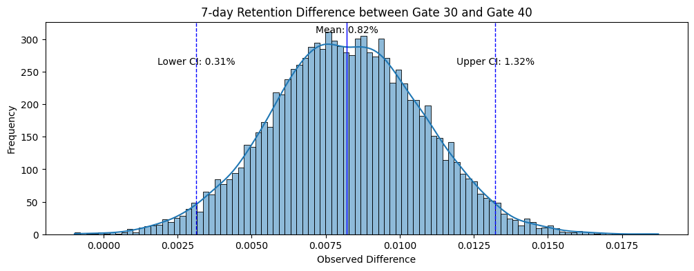

```python
# Calculate p-value - the proportion of bootstrap differences that are as or more extreme than the observed difference
p_value_ret7 = np.mean(bs_ret7_diff <= 0) + np.mean(bs_ret7_diff >= high_ci7-(0-low_ci7))
print(f"P-value 7-day Retention: {round(p_value_ret7,3)}")
print(f"Mean 7-day Retention Proportion Gate 30: {round(bs_mean_30_7*100,3)}%")
print(f"Mean 7-day Retention Proportion Gate 40: {round(bs_mean_40_7*100,3)}%")

plt.figure(figsize=(12, 4))

sns.histplot(bs_ret7_diff, bins=100, kde=True)

plt.axvline(mean_diff_ret7, color='blue', linestyle='solid', linewidth=1)
plt.axvline(high_ci7, color='blue', linestyle='dashed', linewidth=1)
plt.axvline(low_ci7, color='blue', linestyle='dashed', linewidth=1)

# Adding text labels for the lines
plt.text(mean_diff_ret7, plt.ylim()[1]*.95, f'Mean: {mean_diff_ret7*100:.2f}%', ha='center')
plt.text(high_ci7, plt.ylim()[1]*0.8, f'Upper CI: {high_ci7*100:.2f}%', ha='center')
plt.text(low_ci7, plt.ylim()[1]*0.8, f'Lower CI: {low_ci7*100:.2f}%', ha='center')

plt.title('7-day Retention Difference between Gate 30 and Gate 40')
plt.xlabel('Observed Difference')
plt.ylabel('Frequency')
plt.show()
```

There is a difference in 7-day retention between Gates 30 and 40 (0 is not in the confidence interval, and the p-value is less than alpha). Moving the gate from 30 to 40 decreases 7-day retention by 0.82%.

## Conclusion

It is not a good idea to move the gate from 30 to 40 because doing so decreases 7-day retention and has no impact on 1-day retention.

Further analysis should evaluate if there are other variables that impact retention, such as the number of rounds played.